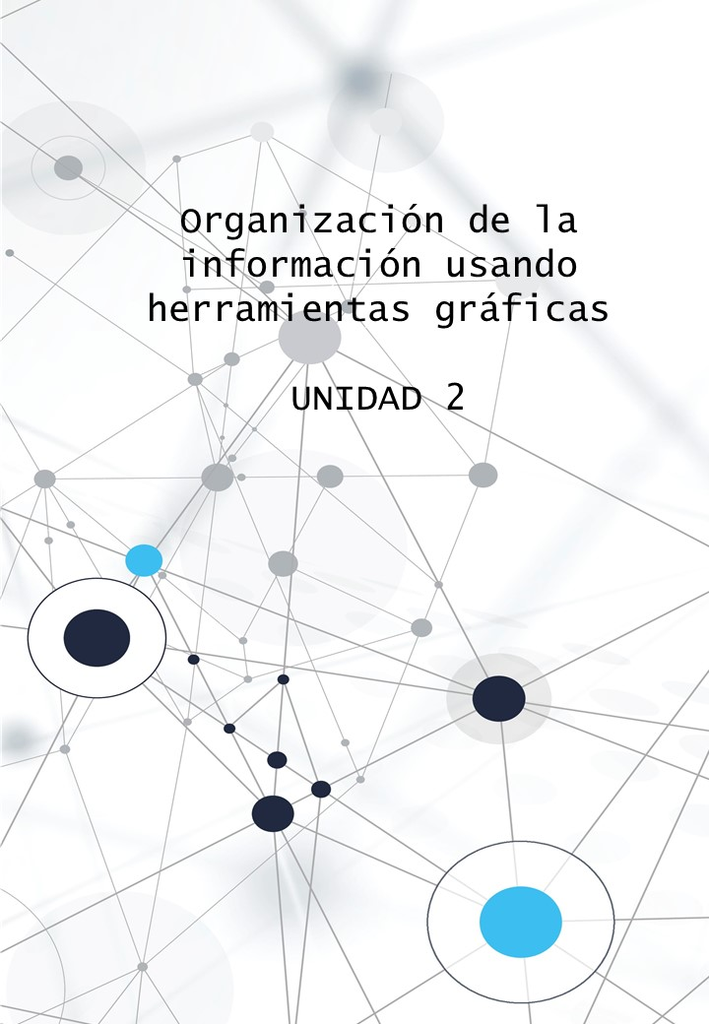

# 1 Ejercicios Unidad 2: Visualización de datos con ggplot2

## 1.1 Base de datos

**Gran Chaco deforestación**

Archivo *chaco.xlsx*

Esta base de datos se encuentra en http://data.globalforestwatch.org y describe la perdida de cobertura de los bosques secos tropicales de la región del Gran Chaco en Paraguay, Argentina y Bolivia.

El monitoreo de la deforestación en el Gran Chaco se ha llevado a cabo por la organización [Guyra Paraguay](http://www.guyra.org.py/index.php?lang=en) desde el año 2011. Se utilizaron imágenes satelitales Landsat de 30 metros de resolución espacial. La interpretación de las zonas forestales bajo cambios de tipo de cobertura, se realiza a través de un análisis multitemporal. Este compara una imagen base de los últimos dos años y una imagen actual del mes en estudio. Los analistas utilizan técnicas de interpretación visual de tono, forma, tamaño, textura, patrón, sombra, y el contexto.

### 1.1.1 Ejercicio 1

- Importe el archivo *chaco.xlsx* como un data frame llamado **chaco**.
- Describa los datos del data frame, identifique qué variables tiene y de qué tipo son.
- Cree la siguiente tabla y guardela como un data frame llamado **tabla**.

| pais | anio | Media | Desvio | Suma | Maximo |
| --- | --- | --- | --- | --- | --- |
| Argentina | 2,011 | 40.74 | 44.88 | 32,506.77 | 427.96 |
| Argentina | 2,012 | 42.45 | 62.21 | 224,461.61 | 1,588.42 |
| Argentina | 2,013 | 66.66 | 228.92 | 221,126.86 | 5,048.50 |
| Argentina | 2,014 | 55.53 | 142.23 | 137,486.52 | 2,828.62 |
| Argentina | 2,015 | 57.61 | 208.11 | 124,043.66 | 3,999.78 |
| Argentina | 2,016 | 315.45 | 601.37 | 116,714.93 | 4,551.72 |
| Argentina | 2,017 | 283.92 | 510.12 | 130,036.53 | 4,200.26 |
| Argentina | 2,018 | 167.41 | 264.71 | 7,366.20 | 1,429.75 |
| Bolivia | 2,011 | 13.44 | 22.92 | 2,782.44 | 249.52 |
| Bolivia | 2,012 | 11.21 | 24.14 | 33,977.32 | 603.50 |
| Bolivia | 2,013 | 20.84 | 123.93 | 42,653.08 | 3,491.97 |
| Bolivia | 2,014 | 11.55 | 56.75 | 41,605.60 | 2,342.89 |
| Bolivia | 2,015 | 25.54 | 216.95 | 55,883.05 | 4,843.18 |
| Bolivia | 2,016 | 504.38 | 754.96 | 35,306.80 | 3,772.14 |
| Bolivia | 2,017 | 714.62 | 1,402.62 | 72,891.48 | 7,966.35 |
| Bolivia | 2,018 | 188.71 | 206.25 | 1,887.09 | 640.73 |
| Paraguay | 2,011 | 63.11 | 53.82 | 148,178.98 | 927.71 |
| Paraguay | 2,012 | 54.27 | 54.94 | 262,432.15 | 863.59 |
| Paraguay | 2,013 | 95.43 | 598.22 | 236,766.53 | 20,816.25 |
| Paraguay | 2,014 | 59.16 | 235.71 | 287,435.28 | 11,638.19 |
| Paraguay | 2,015 | 143.17 | 941.01 | 285,619.87 | 20,628.23 |
| Paraguay | 2,016 | 1,587.83 | 2,695.78 | 203,242.10 | 14,960.93 |
| Paraguay | 2,017 | 1,710.13 | 2,901.82 | 225,736.86 | 16,443.09 |
| Paraguay | 2,018 | 652.35 | 1,171.46 | 5,871.19 | 3,687.01 |

### 1.1.2 Ejercicio 2

- Utilice la tabla creada en el punto anterior para reproducir el siguiente gráfico. Se trata de un gráfico de lineas (`geom_line()`) de los valores promedios de los países en los distintos años.
- Modifique el nombre le eje x (`xlab()`) y agreguele un titulo (`ggtitle( )`).

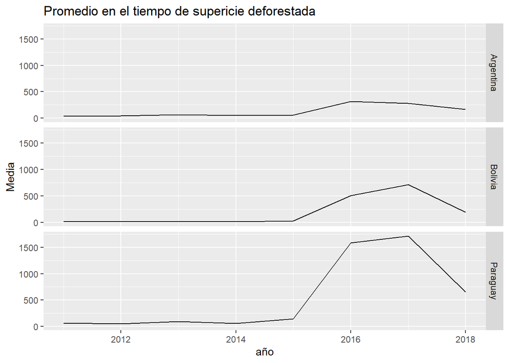

### 1.1.3 Ejercicio 3

- Dibuje un gráfico con un boxplot por cada país con los valores medios.
- Elimine el grillado gris del fondo.
- Escriba el titulo en azul con tamaño de letra 9, en negrita y justificado.

Pista:

`theme(plot.title = element_text(color = 'blue', face = 'bold', size = 9, hjust = 0.5))`

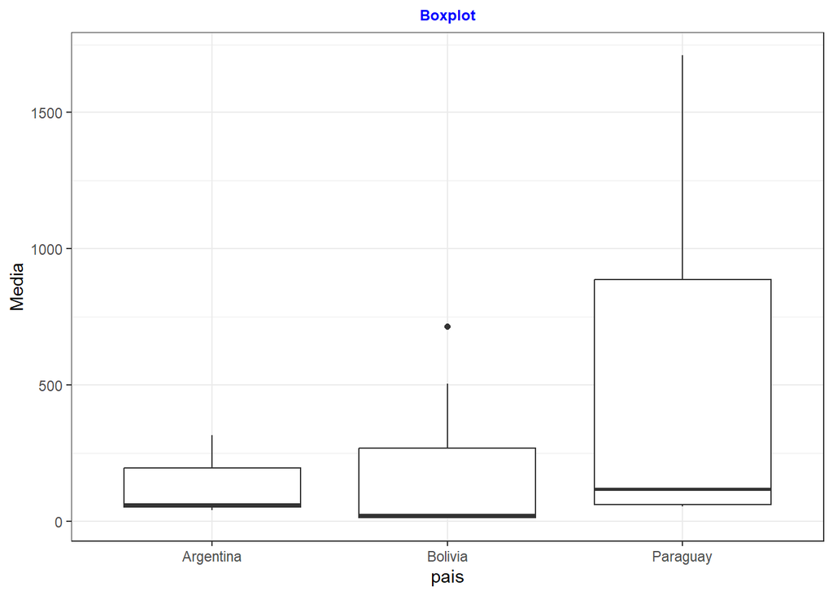

### 1.1.4 Ejercicio 4

- Dibuje un gráfico con un boxplot de los coeficientes de variación por cada país.
- Cambie el color del contorno a rojo.
- Elimine el grillado gris del fondo

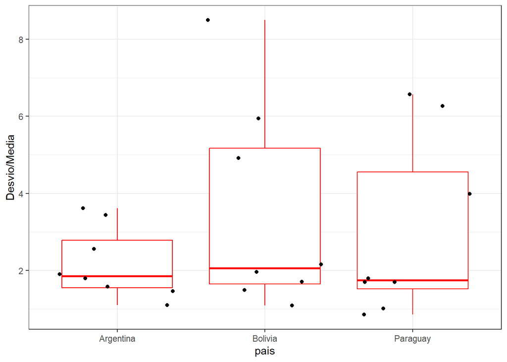

### 1.1.5 Ejercicio 5

Utilizando la tabla generadas por:

```r
tabla2 <- chaco %>%
  group_by(pais, anio, meses)%>%
  summarise(Media = round(mean(sup, na.rm = T),2))
```

Obtenga Histogramas y gráficos de densidad por países.

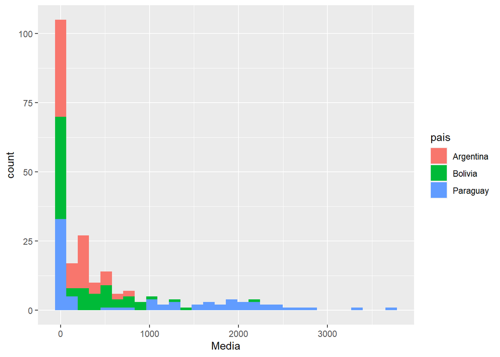

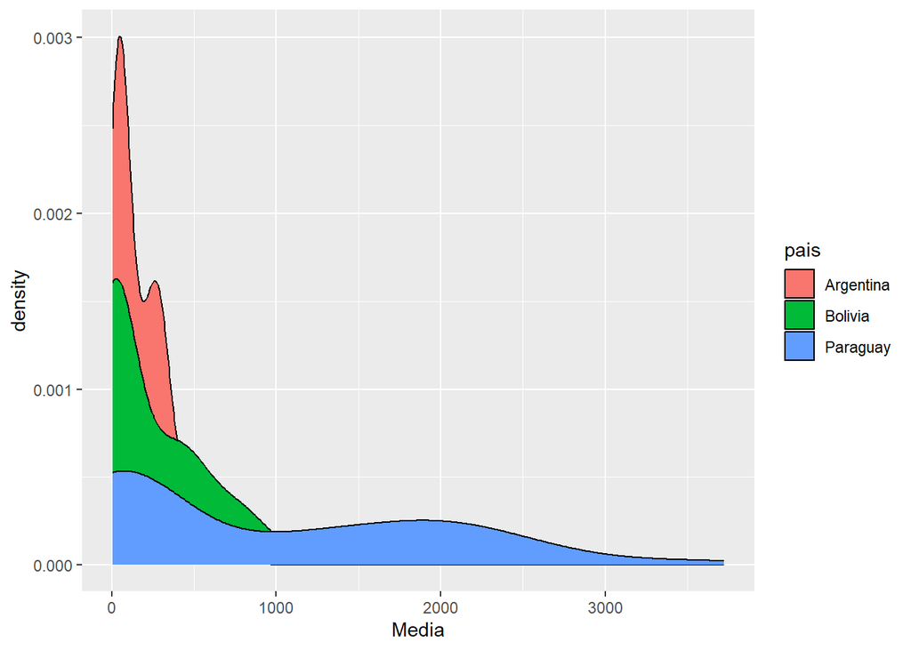

### 1.1.6 Ejercicio 6

Para las tablas obtenidas con este código:

```r
valores.pais <- chaco %>%
  group_by(pais)%>%
  summarise(Media = round(mean(sup, na.rm = T),2),
            Desvio = round(sd(sup, na.rm = T),2),
            Suma=round(sum(sup, na.rm = T),2))`

valores.anio <- chaco %>%
  group_by(anio) %>%
  summarise(Media = round(mean(sup, na.rm = T),2),
            Desvio = round(sd(sup, na.rm = T),2),
            Suma = round(sum(sup, na.rm = T),2))`

valores.anio.pais <- chaco %>%
  group_by(anio, pais) %>%
  summarise(Media = round(mean(sup, na.rm = T),2),
            Desvio = round(sd(sup, na.rm = T),2),
            Suma = round(sum(sup, na.rm = T),2))`
```

genere los siguientes gráficos:

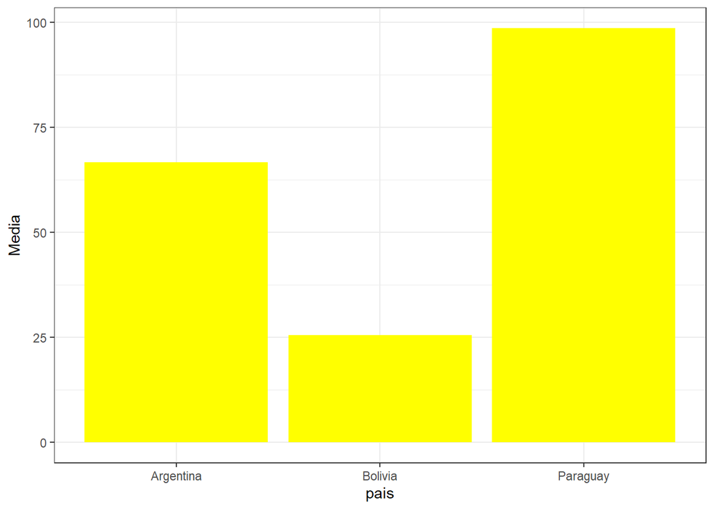

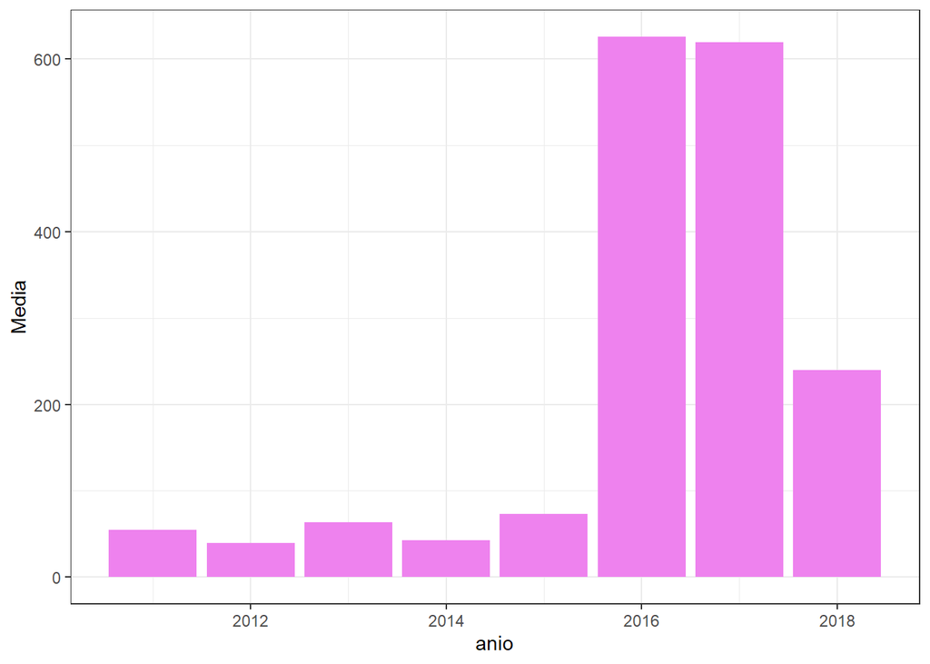

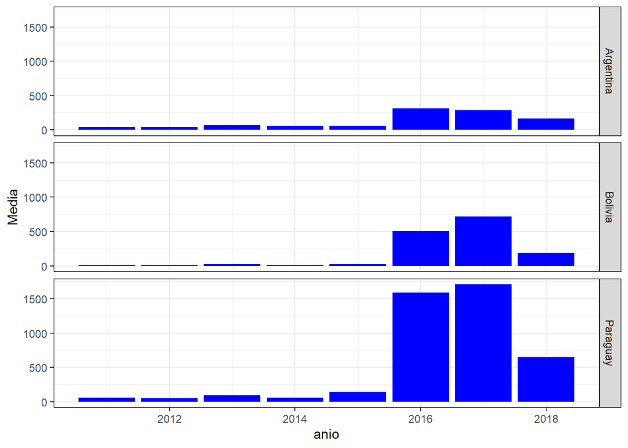

### 1.1.7 Ejercicio 7

Pista:

Necesitará utilizar stat = “summary” para una de las geometrías.

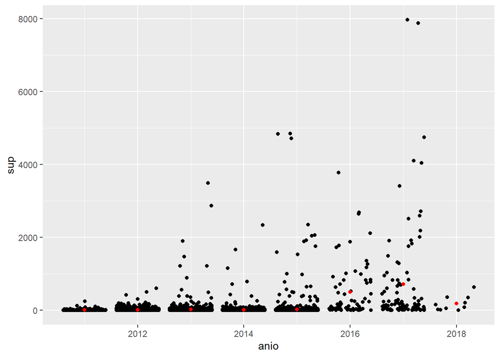